# Question

El diagrama presenta un triángulo rectángulo donde un cateto tiene longitud 1 y la hipotenusa mide √2. Carlos necesita encontrar el valor del cateto x.

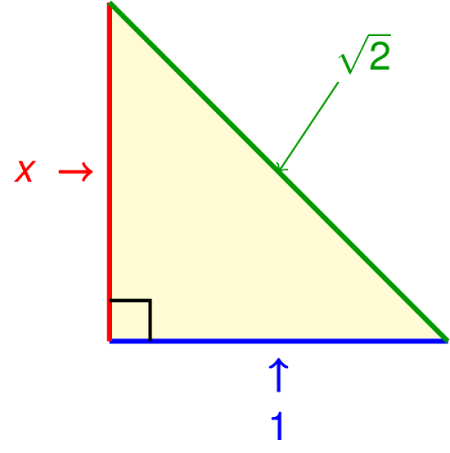

Para resolver este problema, aplica el teorema de Pitágoras siguiendo este procedimiento:

**Paso 1.** Aplicando el teorema de Pitágoras, calcula la hipotenusa usando la fórmula $\sqrt{x^2 + 1^2}$ y verifica que obtienes $\sqrt{2}$.

**Paso 2.** Eleva al cuadrado el resultado del paso 1 y confirma que obtienes el número 2, es decir: $(\sqrt{2})^2 = 2$.

Usando esta información, ¿cuál es el valor del cateto $x$?

## Answerlist

- $x = 1$
- $x = \sqrt{7}$
- $x = 2$
- $x = \frac{5}{2}$

# Solution

Para resolver este problema, debemos analizar la información geométrica y aplicar el teorema de Pitágoras correctamente.

**Análisis de la figura:** - El triángulo rectángulo tiene catetos de longitud $x$ y $1$ - La hipotenusa del triángulo mide $\sqrt{2}$ unidades - Debemos encontrar el valor del cateto $x$

**Resolución paso a paso aplicando el teorema de Pitágoras:**

Del **Paso 1**: Aplicamos el teorema de Pitágoras: $\sqrt{x^2 + 1^2} = \sqrt{2}$

Del **Paso 2**: Elevamos al cuadrado ambos lados: $(\sqrt{2})^2 = 2$

Verificamos el **Paso 2**: $(\sqrt{2})^2 = 2$ ✓

Ahora, elevando al cuadrado la ecuación del **Paso 1**: $(x^2 + 1^2) = (\sqrt{2})^2$

Simplificando: $x^2 + 1 = 2$

Despejando $x^2$: $x^2 = 2 - 1 = 1$

Por lo tanto: $x = \sqrt{1} = 1$

**Verificación geométrica:** Si $x = 1$, entonces $\sqrt{1^2 + 1^2} = \sqrt{2}$, y $(\sqrt{2})^2 = 2$ ✓

## Answerlist

- Verdadero. Aplicando correctamente el teorema de Pitágoras: $x^2 + 1 = 2$, por lo tanto $x = 1$.
- Falso. Error: Error: confunde la diagonal con el cateto buscado
- Falso. Error: Error: usa el resultado final (2) como valor del cateto
- Falso. Error: Error: aplica incorrectamente el teorema de Pitágoras

# Meta-information

exname: Cateto triangulo rectangulo teorema Pitagoras extype: schoice exsolution: 1000 exshuffle: TRUE exsection: Geometria/Teorema de Pitagoras

# Metadatos ICFES obligatorios

icfes: competencia: formulacion_ejecucion nivel_dificultad: 2 contenido: categoria: geometria tipo: generico contexto: matematico eje_axial: eje2 componente: geometrico_metrico